# Hii-ruut-test

Indrek Soidla

2022-11-11

```r
library(haven)
library(tidyverse)
library(summarytools)
library(descr)
library(rcompanion)
library(Hmisc)
library(corrplot)
library(lattice)
library(GGally)
library(corrgram)
library(weights)
library(magrittr)
```

# Hii-ruut-test

Teeme siin läbi õppevideotes esitatud näite, kus uuriti soo ja erakondliku eelistuse seost, et saada aimu, kuidas hii-ruut-statistikut arvutada ja seda paremini tõlgendada R-s.

## Tehniline ettevalmistus

Loeme sisse ESS 8. küsitluslaine Eesti andmed.

```r
ee8 <- read_spss("data/ee8.sav")
```

Erakond, mille poolt vastaja hääletas 2015. aasta Riigikogu valimistel, on kirjas tunnuses `prtvtfee`. Vaatame tunnuse kategooriate nimetusi, kodeerime tunnuse ümber. Eri väikeparteide poolt hääletanud on eraldi kategooriates, paneme osad kategooriad kokku, et jaotus oleks ülevaatlikum ja vastaks hii-ruut-testi eeldustele. Kodeerime ümber ka soo tunnuse.

```r
attributes(ee8$prtvtfee)
```

```
## $label
## [1] "Party voted for in last national election, Estonia"
##
## $format.spss
## [1] "F2.0"
##
## $class
## [1] "haven_labelled" "vctrs_vctr"     "double"
##
## $labels
##               Eesti Reformierakond                  Eesti Keskerakond
##                                  1                                  2
## Erakond Isamaa ja Res Publica Liit       Sotsiaaldemokraatlik Erakond
##                                  3                                  4
##         Erakond Eestimaa Rohelised  Eesti Konservatiivne Rahvaerakond
##                                  5                                  6
##             Eesti Iseseisvuspartei          Üksikkandidaadid või muud
##                                  9                                 10
##                  Eesti Vabaerakond              Rahva Ühtsuse Erakond
##                                 11                                 12
##     Eestimaa Ühendatud Vasakpartei                     Not applicable
##                                 13                                 66
##                            Refusal                         Don't know
##                                 77                                 88
##                          No answer
##                                 99
```

```r
attributes(ee8$gndr)
```

```
## $label
## [1] "Gender"
##
## $format.spss
## [1] "F1.0"
##
## $class
## [1] "haven_labelled" "vctrs_vctr"     "double"
##
## $labels
##      Male    Female No answer
##         1         2         9
```

```r
ee8 <- ee8 %>%
  mutate(prtvtfee2 = recode(as.factor(prtvtfee),
                            "1" = "RE",
                            "2" = "KE",
                            "3" = "IRL",
                            "4" = "SDE",
                            "6" = "EKRE",
                            "5" = "VP",
                            "9" = "VP",
                            "10" = "VP",
                            "12" = "VP",
                            "13" = "VP",
                            "11" = "VE"),
         gndr2 = recode(as.factor(gndr),
                        "1" = "Mees",
                        "2" = "Naine"))
```

## Risttabelite koostamine

Varasemalt oleme kaalutud andmete põhjal risttabeli ehk tunnuste ühisjaotuse saanud funktsiooniga `ctable` paketist `summarytools`. Vastavad näited on järgnevalt ära toodud, aga kuna oleme seda varem kirjeldava statistika osas õppinud, seega pikemalt siin ei peatu; eri protsentjaotuste tõlgendus on toodud õppevideos.

```r
ctable(ee8$gndr2, ee8$prtvtfee2, weight = ee8$pspwght, useNA = "no", prop = "t", round.digits = 0)
```

```
## Cross-Tabulation, Total Proportions
## gndr2 * prtvtfee2
## Data Frame: ee8
##
## ------- ----------- ----------- ----------- ----------- ----------- --------- --------- --------- --------------
##           prtvtfee2          RE          KE         IRL         SDE        VP      EKRE        VE          Total
##   gndr2
##    Mees               150 (13%)   124 (11%)    68 ( 6%)    74 ( 6%)   23 (2%)   41 (3%)   37 (3%)     516 ( 44%)
##   Naine               216 (18%)   145 (12%)    72 ( 6%)   124 (11%)   23 (2%)   29 (2%)   52 (4%)     662 ( 56%)
##   Total               367 (31%)   269 (23%)   140 (12%)   198 (17%)   47 (4%)   69 (6%)   89 (8%)   1178 ( 100%)
## ------- ----------- ----------- ----------- ----------- ----------- --------- --------- --------- --------------
```

```r
ctable(ee8$gndr2, ee8$prtvtfee2, weight = ee8$pspwght, useNA = "no", prop = "c", round.digits = 0)
```

```
## Cross-Tabulation, Column Proportions
## gndr2 * prtvtfee2
## Data Frame: ee8
##
## ------- ----------- ------------- ------------- ------------- ------------- ------------ ------------ ------------ --------------
##           prtvtfee2            RE            KE           IRL           SDE           VP         EKRE           VE          Total
##   gndr2
##    Mees                150 ( 41%)    124 ( 46%)     68 ( 48%)     74 ( 37%)    23 ( 50%)    41 ( 59%)    37 ( 41%)     516 ( 44%)
##   Naine                216 ( 59%)    145 ( 54%)     72 ( 52%)    124 ( 63%)    23 ( 50%)    29 ( 41%)    52 ( 59%)     662 ( 56%)
##   Total               367 ( 100%)   269 ( 100%)   140 ( 100%)   198 ( 100%)   47 ( 100%)   69 ( 100%)   89 ( 100%)   1178 ( 100%)
## ------- ----------- ------------- ------------- ------------- ------------- ------------ ------------ ------------ --------------
```

```r
ctable(ee8$gndr2, ee8$prtvtfee2, weight = ee8$pspwght, useNA = "no", prop = "r", round.digits = 0)
```

```
## Cross-Tabulation, Row Proportions
## gndr2 * prtvtfee2
## Data Frame: ee8
##
## ------- ----------- ----------- ----------- ----------- ----------- --------- --------- --------- -------------
##           prtvtfee2          RE          KE         IRL         SDE        VP      EKRE        VE         Total
##   gndr2
##    Mees               150 (29%)   124 (24%)    68 (13%)    74 (14%)   23 (5%)   41 (8%)   37 (7%)    516 (100%)
##   Naine               216 (33%)   145 (22%)    72 (11%)   124 (19%)   23 (3%)   29 (4%)   52 (8%)    662 (100%)
##   Total               367 (31%)   269 (23%)   140 (12%)   198 (17%)   47 (4%)   69 (6%)   89 (8%)   1178 (100%)
## ------- ----------- ----------- ----------- ----------- ----------- --------- --------- --------- -------------
```

## Hii-ruut-statistiku arvutamine

Hii-ruut-statistiku saab arvutada ka funktsiooniga `ctable`, aga teeme seda paketi `descr` funktsiooni `crosstab` abil, sest see võimaldab tellida ka tunnuste teoreetilise ühisjaotuse (ja võimaldab samuti andmeid kaaluda).

Arvutame hii-ruut-statistiku. Kuna saame automaatselt ka risttabeli, esitame selles informatiivsuse mõttes ka reaprotsendid. Automaatselt esitatakse väljundina ka risttabel mosaiikdiagrammi ehk Marimekko-diagrammi kujul - see ei ole küll väga täpne, sest puuduvad ühikud telgedel, seetõttu sobib see diagramm antud kujul ehk ainult omaette uurimiseks, mitte teistele esitamiseks.

Kui risttabelis on esitatud reaprotsendid, siis diagramm on vaikeseadena koostatud veeruprotsentide alusel.

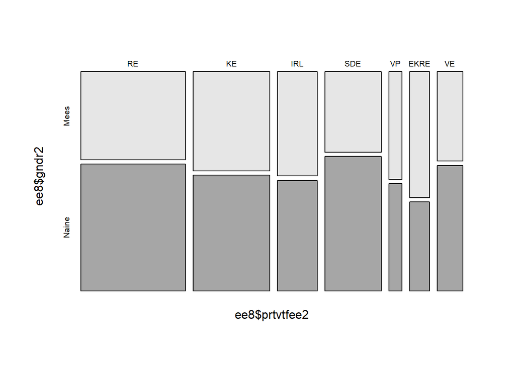

```
##    Cell Contents
## |-------------------------|
## |                   Count |
## |             Row Percent |
## |-------------------------|
##
## =======================================================================
##              ee8$prtvtfee2
## ee8$gndr2       RE      KE     IRL     SDE     VP   EKRE     VE   Total
## -----------------------------------------------------------------------
## Mees          150     124      68      74     23     41     37     517
##              29.0%   24.0%   13.2%   14.3%   4.4%   7.9%   7.2%   43.9%
## -----------------------------------------------------------------------
## Naine         216     145      72     124     23     29     52     661
##              32.7%   21.9%   10.9%   18.8%   3.5%   4.4%   7.9%   56.1%
## -----------------------------------------------------------------------
## Total         366     269     140     198     46     70     89    1178
## =======================================================================
##
## Statistics for All Table Factors
##
## Pearson's Chi-squared test
## ------------------------------------------------------------
## Chi^2 = 13.46532      d.f. = 6      p = 0.0362
##
##         Minimum expected frequency: 20.18846
```

```r
crosstab(ee8$gndr2, ee8$prtvtfee2, weight = ee8$pspwght, prop.r = TRUE, chisq = TRUE)
```

Näeme, et hii-ruutstatistiku väärtus, vabadusastmete arv ja olulisuse tõenäosus on täpselt samad, mis õppevideotes. Olulisuse nivool 0,05 saame öelda, et erakondlik eelistus oli 2015. aasta Riigikogu valimistel seotud sooga. Teisiti sõnastades saame öelda, et erakondliku eelistuse jaotus oli Riigikogu valimas käinute seas meeste ja naiste hulgas erinev. Või teistpidi, sooline jaotus oli eri erakondade valijate seas erinev - kuna hii-ruut-test põhineb tunnuste absoluutsel ühisjaotusel ehk indiviidide arvudel lahtrites (mitte ühte- või teistpidi arvutatud protsentidel), siis kehtivad mõlemad tõlgendused. Milliste erakondade valijate sooline jaotus üksteisest erines, seda hii-ruut-test meile siiski ei ütle - näiteks ei saa me selle testi põhjal öelda, kas Reformierakonna ja Keskerakonna valijate sooline jaotus erines. Saaksime seda uurida, tehes risttabeli ja hii-ruut-testi ainult Reformierakonna ja Keskerakonna valijate andmete põhjal. Peame samas arvestama, et kuna indiviidide hulk kokku on sel juhul väiksem, ilmneb statistiliselt oluline seos alles jaotuste märkimisväärselt suurema erinevuse puhul. Ka tuleb silmas pidada, et kui teeksime selliseid kahe erakonna valijate võrdlusi suuremal hulgal, siis suureneb ka valepositiivse tulemuse võimalus (st kokku on vähemalt ühe testi puhul esimest liiki vea tegemise oht suurem kui iga üksiku testi puhul eraldi).

## Hii-ruut-testi eelduste kontrollimine

Et kontrollida hii-ruut-testi eelduste täidetust, oleks vaja näha ka teoreetilist ühisjaotust, st indiviidide hüpoteetilist jaotust risttabelis juhul, kui vaadeldavad tunnused üldse seotud ei oleks. Et tabel liiga kirjuks ei läheks, jätame eelnevast käsust reaprotsendid välja ja lisame argumendi `expected = TRUE`.

```r
crosstab(ee8$gndr2, ee8$prtvtfee2, weight = ee8$pspwght, expected = TRUE, chisq = TRUE, plot = FALSE)
```

```
##    Cell Contents
## |-------------------------|
## |                   Count |
## |         Expected Values |
## |-------------------------|
##
## ======================================================================
##              ee8$prtvtfee2
## ee8$gndr2       RE      KE    IRL     SDE     VP   EKRE     VE   Total
## ----------------------------------------------------------------------
## Mees           150     124     68      74     23     41     37     517
##              160.6   118.1   61.4    86.9   20.2   30.7   39.1
## ----------------------------------------------------------------------
## Naine          216     145     72     124     23     29     52     661
##              205.4   150.9   78.6   111.1   25.8   39.3   49.9
## ----------------------------------------------------------------------
## Total          366     269    140     198     46     70     89    1178
## ======================================================================
##
## Statistics for All Table Factors
##
## Pearson's Chi-squared test
## ------------------------------------------------------------
## Chi^2 = 13.46532      d.f. = 6      p = 0.0362
##
##         Minimum expected frequency: 20.18846
```

Nagu ka eelnevalt õppevideost nägime, ükski teoreetilise jaotuse sagedus ei ole väiksem viiest, seega hii-ruut-testi eeldused on täidetud. Kui oleksime teinud hii-ruut-testi algse erakondliku eelistuse tunnusega `prtvtfee`, oleks teoreetiline jaotus sisaldanud lahtreid, kus sagedus on alla ühe ja väiksema sagedusega kui viis lahtreid oleks 20%. Funktsioon `crosstab` annab ka ise vastava hoiatuse.

```r
crosstab(ee8$gndr2, ee8$prtvtfee, weight = ee8$pspwght, expected = TRUE, chisq = TRUE, plot = FALSE)
```

```
##    Cell Contents
## |-------------------------|
## |                   Count |
## |         Expected Values |
## |-------------------------|
##
## ===========================================================================================
##              Party voted for in last national election, Estonia
## ee8$gndr2        1       2      3       4      5      6      9     10     11     12   Total
## -------------------------------------------------------------------------------------------
## Mees           150     124     68      74      9     41      0     13     37      1     517
##              160.6   118.1   61.4    86.9    5.3   30.7    0.4   14.0   39.1    0.4
## -------------------------------------------------------------------------------------------
## Naine          216     145     72     124      3     29      1     19     52      0     661
##              205.4   150.9   78.6   111.1    6.7   39.3    0.6   18.0   49.9    0.6
## -------------------------------------------------------------------------------------------
## Total          366     269    140     198     12     70      1     32     89      1    1178
## ===========================================================================================
##
## Statistics for All Table Factors
##
## Pearson's Chi-squared test
## ------------------------------------------------------------
## Chi^2 = 19.68323      d.f. = 9      p = 0.02
##
##         Minimum expected frequency: 0.4388795
## Cells with Expected Frequency < 5: 4 of 20 (20%)
```

## Standardiseeritud ruutjäägid

Lisaks teoreetilisele jaotusele saame funktsiooni `crosstab` puhul tellida standardiseeritud ruutjäägid, mis võimaldavad vahetumalt näha, millised lahtrid panustavad hii-ruut-statistikusse enam ehk millistes lahtrites on kõige suurem erinevus teoreetilisest jaotusest (hii-ruut-statistiku väärtus on ju standardiseeritud ruutjääkide summa).

```r
crosstab(ee8$gndr2, ee8$prtvtfee2, weight = ee8$pspwght, expected = TRUE, chisq = TRUE, prop.chisq = TRUE, plot = FALSE)
```

```
##    Cell Contents
## |-------------------------|
## |                   Count |
## |         Expected Values |
## | Chi-square contribution |
## |-------------------------|
##
## ==========================================================================
##              ee8$prtvtfee2
## ee8$gndr2       RE      KE     IRL     SDE      VP    EKRE      VE   Total
## --------------------------------------------------------------------------
## Mees           150     124      68      74      23      41      37     517
##              160.6   118.1    61.4    86.9    20.2    30.7    39.1
##              0.703   0.299   0.700   1.914   0.392   3.439   0.109
## --------------------------------------------------------------------------
## Naine          216     145      72     124      23      29      52     661
##              205.4   150.9    78.6   111.1    25.8    39.3    49.9
##              0.550   0.234   0.547   1.497   0.306   2.690   0.085
## --------------------------------------------------------------------------
## Total          366     269     140     198      46      70      89    1178
## ==========================================================================
##
## Statistics for All Table Factors
##
## Pearson's Chi-squared test
## ------------------------------------------------------------
## Chi^2 = 13.46532      d.f. = 6      p = 0.0362
##
##         Minimum expected frequency: 20.18846
```

Antud juhul on näha, et suurim erinevus tegeliku ja teoreetilise jaotuse vahel (lähtudes standardiseeritud ruutjääkidest) on EKRE ja SDE valijate seas, st nende seas erineb mees- ja naisvastajate jaotus kõige rohkem meeste ja naiste jaotusest kõigi hääletanud vastajate seas. Sarnase järelduse oleksime saanud teha ka risttabeli veeruprotsentide põhjal, siin on see ehk veel selgemalt esile toodud.

## Crameri *V* arvutamine

Arvutame ka Crameri *V*. Võime seda ise teha või kasutada funktsiooni `cramerV` paketist `rcompanion`.

Ise:

```r
sqrt(13.465 / (1178 * (2 - 1)))
```

```
## [1] 0.106913
```

Funktsioon `cramerV` tahab ainukese sisendina saada risttabelit, mille põhjal hii-ruut-statistik on arvutatud. Kui omistame hii-ruut-testi tulemused uuele objektile `hrtest`, siis vastav risttabel on alamobjektis `hrtest$tab` (käsuga `View(hrtest)` saate selles ise veenduda).

```r
hrtest <- crosstab(ee8$prtvtfee2, ee8$gndr, weight = ee8$pspwght, chisq = TRUE, plot = FALSE)

cramerV(hrtest$tab)
```

```
## Cramer V
##   0.1069
```

## Ülesanne 1

Kas haridustase on seotud hinnangutega väitele, et töökohtade nappuse korral peaks meestel olema eelisõigus tööd saada (st kas saab väita seose esinemist rahvastikus)? Kasuate ESS Eesti 8. laine andmeid. Sõnastage null- ja alternatiivhüpotees ning testige hüpoteesipaari olulisuse nivool 0,05. Enne hii-ruut-testi tegemist kontrollige testi eelduste täidetust. Kui seos esineb, püüdke seda ka sisuliselt iseloomustada (kuidas mingi haridustaseme esindajad oma suhtumise poolest üldiselt erinevad, kas seost võiks pidada pigem nõrgaks, mõõdukaks või tugevaks), näidake lahenduses ära, milliste näitajate põhjal missuguse tõlgenduseni jõuate.

Tunnuste ümberkodeerimise käsud:

```r
ee8 <- ee8 %>%
  mutate(mnrgtjb2 = recode(as.factor(mnrgtjb),
                           "1" = "Olen täiesti nõus",
                           "2" = "Olen nõus",
                           "3" = "Ei nõustu ega ole vastu",
                           "4" = "Ei ole nõus",
                           "5" = "Ei ole üldse nõus"),
         haridus = case_when(edulvlb <= 213 ~ "Põhiharidus või madalam",
                         edulvlb == 313 ~ "Keskharidus",
                         edulvlb > 213 & edulvlb < 600 ~ "Kutseharidus",
                         edulvlb >= 600 ~ "Kõrgharidus"))

ee8$haridus <- fct_relevel(ee8$haridus, "Põhiharidus või madalam", "Kutseharidus", "Keskharidus", "Kõrgharidus")
```

Esitage ülesande lahendus kas:

- Rmarkdowniga tehtud html-failina või
- nagu varasemalt skriptifailis, kuhu lisage ka lahenduseni jõudmiseks vajalikud eelnevad käsud (nt pakettide laadimine, andmete sisselugemine).

Proovige ülesanne teha kõigepealt iseseisvalt eelneva koodi põhjal. Kui see ei õnnestu, siis…

**väljundi nägemiseks klikkige siia**

```
##    Cell Contents
## |-------------------------|
## |                   Count |
## |         Expected Values |
## |-------------------------|
##
## ===============================================================================
##                 ee8$haridus
## ee8$mnrgtjb2    Põhhrds võ m   Kutseharidus   Keskharidus   Kõrgharidus   Total
## -------------------------------------------------------------------------------
## Oln täst nõs              15             18            11             5      49
##                          7.5           17.0           9.0          15.5
## -------------------------------------------------------------------------------
## Olen nõus                 52             64            27            41     184
##                         28.3           63.7          33.7          58.3
## -------------------------------------------------------------------------------
## E nõst e o v              55            112            46            61     274
##                         42.2           94.9          50.1          86.7
## -------------------------------------------------------------------------------
## Ei ole nõus              129            350           169           319     967
##                        149.0          335.0         176.9         306.2
## -------------------------------------------------------------------------------
## E ol ülds nõ              59            153           115           211     538
##                         82.9          186.4          98.4         170.3
## -------------------------------------------------------------------------------
## Total                    310            697           368           637    2012
## ===============================================================================
```

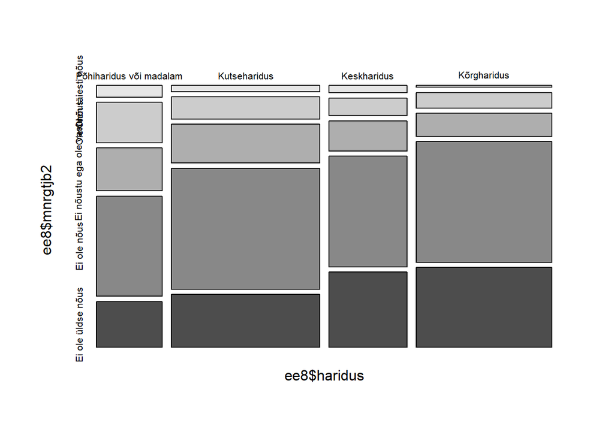

```
##    Cell Contents
## |-------------------------|
## |                   Count |
## | Chi-square contribution |
## |          Column Percent |
## |-------------------------|
##
## ================================================================================
##                 ee8$haridus
## ee8$mnrgtjb2    Põhhrds võ m   Kutseharidus   Keskharidus   Kõrgharidus    Total
## --------------------------------------------------------------------------------
## Oln täst nõs             15             18            11             5       49
##                       7.352          0.062         0.463         7.125
##                         4.8%           2.6%          3.0%          0.8%
## --------------------------------------------------------------------------------
## Olen nõus                52             64            27            41      184
##                      19.729          0.001         1.316         5.111
##                        16.8%           9.2%          7.3%          6.4%
## --------------------------------------------------------------------------------
## E nõst e o v             55            112            46            61      274
##                       3.871          3.074         0.338         7.643
##                        17.7%          16.1%         12.5%          9.6%
## --------------------------------------------------------------------------------
## Ei ole nõus             129            350           169           319      967
##                       2.682          0.673         0.350         0.539
##                        41.6%          50.2%         45.9%         50.1%
## --------------------------------------------------------------------------------
## E ol ülds nõ             59            153           115           211      538
##                       6.887          5.977         2.800         9.710
##                        19.0%          22.0%         31.2%         33.1%
## --------------------------------------------------------------------------------
## Total                   310            697           368           637     2012
##                        15.4%          34.6%         18.3%         31.7%
## ================================================================================
##
## Statistics for All Table Factors
##
## Pearson's Chi-squared test
## ------------------------------------------------------------
## Chi^2 = 85.70144      d.f. = 12      p = 3.34e-13
##
##         Minimum expected frequency: 7.549702
```

```
## Cramer V
##   0.1192
```

**lahenduse nägemiseks klikkige siia**

```r
crosstab(ee8$mnrgtjb2, ee8$haridus, weight = ee8$pspwght, expected = TRUE)
crosstab(ee8$mnrgtjb2, ee8$haridus, weight = ee8$pspwght, prop.chisq = TRUE, prop.c = TRUE, chisq = TRUE)

hrtest_mnrgtjb2_haridus <- crosstab(ee8$mnrgtjb2, ee8$haridus, weight = ee8$pspwght, prop.chisq = TRUE, prop.c = TRUE, chisq = TRUE)
cramerV(hrtest_mnrgtjb2_haridus$tab)
```

# Korrelatsioonanalüüs

ESS7 (2014) ankeedis on küsitud, kui oluliseks peaks pidama erinevaid tegureid, otsustades sisserändajate Eestisse lubamise üle (küsimused D1-D6, tunnused `qfimedu:qfimcmt`). Uurime nende tunnuste vahelisi korrelatsioone inimeste seas, kes ise on sündinud väljaspool Eestit. Eeldame esmalt ülesande lihtsustamiseks, et tunnuste vahel on lineaarne seos. Millised tunnused on üksteisega rohkem seotud, millised vähem? Milliseid järeldusi saab sellise analüüsi põhjal teha?

Loeme sisse Eesti 7. laine andmed.

```r
ee7 <- read_spss("data/ee7.sav")
```

## Lineaarse korrelatsioonikordaja arvutamine

Selekteerime vajalikud tunnused andmestikust `ee7` ja omistame nad uuele objektile `imp`. Kasutame korrelatsioonimaatriksi loomiseks funktsiooni `rcorr` paketist `Hmisc`, see funktsioon eeldab, et andmed on maatriksi kujul, seetõttu muudame objekti `imp` ka kohe maatriksiks.

ESS-i andmete analüüsimisel peaks üldjuhul kasutama ka kaale, aga teeme siinkohal lihtsuse huvides ja eelnevalt läbitehtu harjutamiseks ülesande esmalt läbi ilma kaaludeta.

```r
imp <- ee7 %>%
  filter(brncntr == 2) %>%
  select(qfimedu:qfimcmt) %>%
  as.matrix()

rcorr(imp)
```

```
##         qfimedu qfimlng qfimchr qfimwht qfimwsk qfimcmt
## qfimedu    1.00    0.38    0.17    0.16    0.49    0.34
## qfimlng    0.38    1.00    0.37    0.13    0.36    0.20
## qfimchr    0.17    0.37    1.00    0.43    0.27    0.29
## qfimwht    0.16    0.13    0.43    1.00    0.24    0.28
## qfimwsk    0.49    0.36    0.27    0.24    1.00    0.54
## qfimcmt    0.34    0.20    0.29    0.28    0.54    1.00
##
## n
##         qfimedu qfimlng qfimchr qfimwht qfimwsk qfimcmt
## qfimedu     394     390     383     388     392     389
## qfimlng     390     394     385     389     393     388
## qfimchr     383     385     388     384     387     383
## qfimwht     388     389     384     392     391     388
## qfimwsk     392     393     387     391     398     391
## qfimcmt     389     388     383     388     391     392
##
## P
##         qfimedu qfimlng qfimchr qfimwht qfimwsk qfimcmt
## qfimedu         0.0000  0.0007  0.0021  0.0000  0.0000
## qfimlng 0.0000          0.0000  0.0098  0.0000  0.0000
## qfimchr 0.0007  0.0000          0.0000  0.0000  0.0000
## qfimwht 0.0021  0.0098  0.0000          0.0000  0.0000
## qfimwsk 0.0000  0.0000  0.0000  0.0000          0.0000
## qfimcmt 0.0000  0.0000  0.0000  0.0000  0.0000
```

Maatriksis olulise info leidmiseks isegi lihtsam on korrelatsioonimaatriksi visualiseerimine, kasutame selleks funktsiooni `corrplot` samanimelisest paketist. `corrplot` visualiseerib korrelatsioonikordajaid, seetõttu peame funktsiooni `rcorr` tulemuste objektist `imp_corr` andma `corrplot`’i esimeseks argumendiks kolmest maatriksikst ainult esimese. Argumendiga `method = "number"` seadistame diagrammile korrelatsioonikordajad arvudena (võite funktsiooni `corrplot` abifailist uurida ja katsetada, milliseid teisi võimalusi see argument pakub).

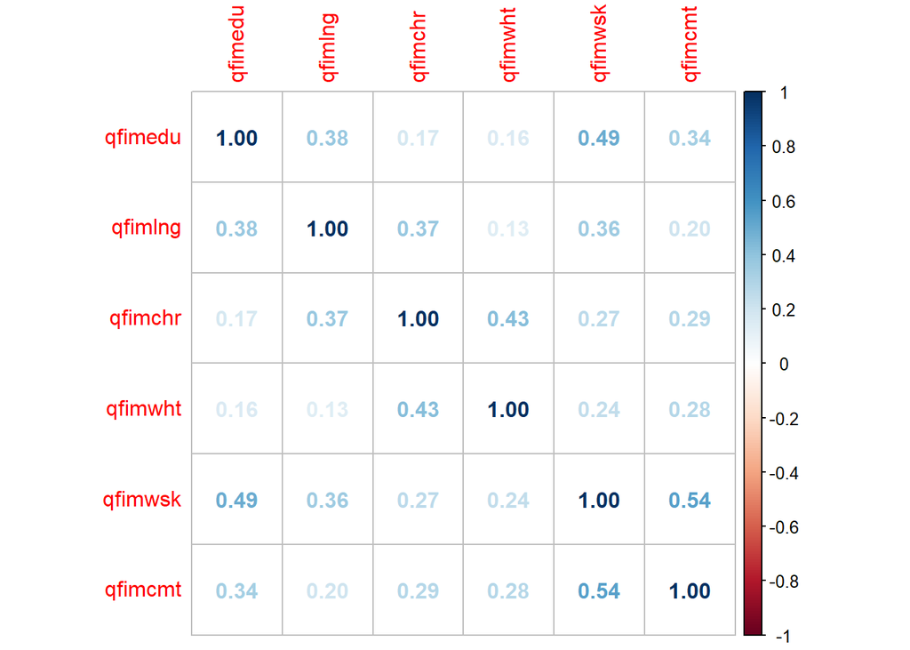

```r
imp_corr <- rcorr(imp)
corrplot(imp_corr[[1]], method = "number")
```

Näeme, et tunnuste nimed pole joonisel just eriti informatiivsed, need võiks asendada eestikeelsete nimedega. Corrplot võtab tunnuste nimed korrelatsioonimaatriksi ridade ja veergude nimedest, seega oleks vaja need ära muuta. Sümbolikombinatsiooniga `\n` saab tähistada reavahetust. Sobivad ridade/veergude nimetused on kõige parem sõnastada [eestikeelse ankeedi alusel](https://uhiskond.ut.ee/sites/default/files/2022-02/ess7_eesti_keelne_ankeet_13.08.pdf), vt küsimused D1-D6.

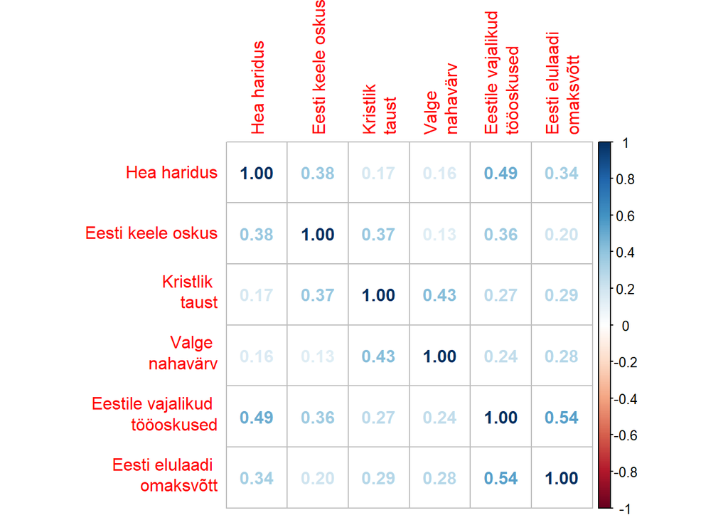

```r
nimed <- c("Hea haridus", "Eesti keele oskus", "Kristlik \ntaust", "Valge \nnahavärv", "Eestile vajalikud \ntööoskused", "Eesti elulaadi \nomaksvõtt")
colnames(imp_corr[[1]]) <- nimed
rownames(imp_corr[[1]]) <- nimed

corrplot(imp_corr[[1]], method = "number")
```

Näeme, et teineteisega on kõige tugevamalt seotud Eestile vajalike tööoskuste olulisus ja hea hariduse olulisus, kristliku tausta olulisus ja valge nahavärvi olulisus, ning Eestile vajalike tööoskuste olulisus ja Eesti elulaadi omaksvõtmise olulisus. Võib öelda, et need seosed on tugevad või mõõdukalt tugevad. Sisuliste järelduste osas saab nt öelda, et mida olulisem on vastajale sisserände lubamise üle otsustamisel kristlik taust, seda olulisem on reeglina ka valge nahavärvi olulisus. Võimalik, et mõlemale küsimusele vastamist on mõjutanud positiivsem suhtumine lähedasest kultuuriruumist või isegi geograafiliselt lähemast piirkonnast pärit immigrantide suhtes.

## Lineaarse korrelatsioonikordaja arvutamise eeldused

Ülesande lihtsustamiseks eeldasime, et tunnuste vahel esineb lineaarne seos. Kui me poleks seda eeldanud, vaid tahtnuksime seda ise järele kontrollida (mis oleks mõttekas), oleks seda saanud visuaalse vaatluse põhjal teha nt funktsiooniga `splom` paketist `lattice`, funktsiooniga `ggpairs` paketist `GGally` või funktsiooniga `corrgram` paketist `corrgram`. NB! Sirgjooni joonistel ei tohiks käsitleda kui tõendeid lineaarse seose olemasolust, jälgida tuleks, kuivõrd langeb sirgjoon kokku seosega, mida näeme punktiparvest joonisel.

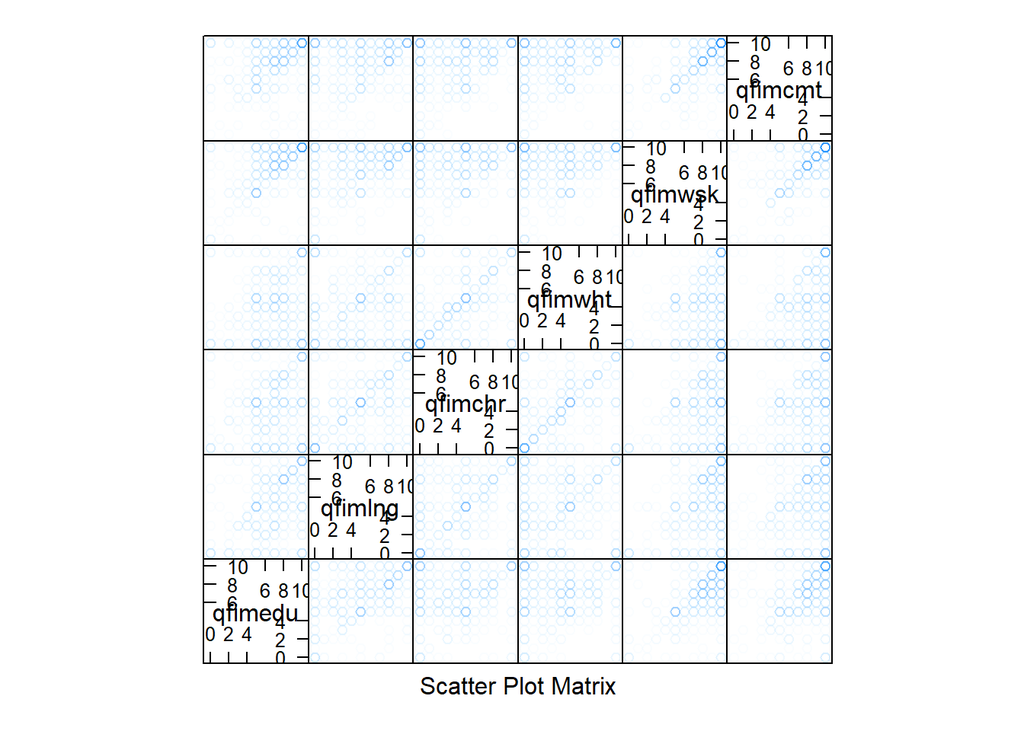

```r
splom(imp, alpha = 0.02)
```

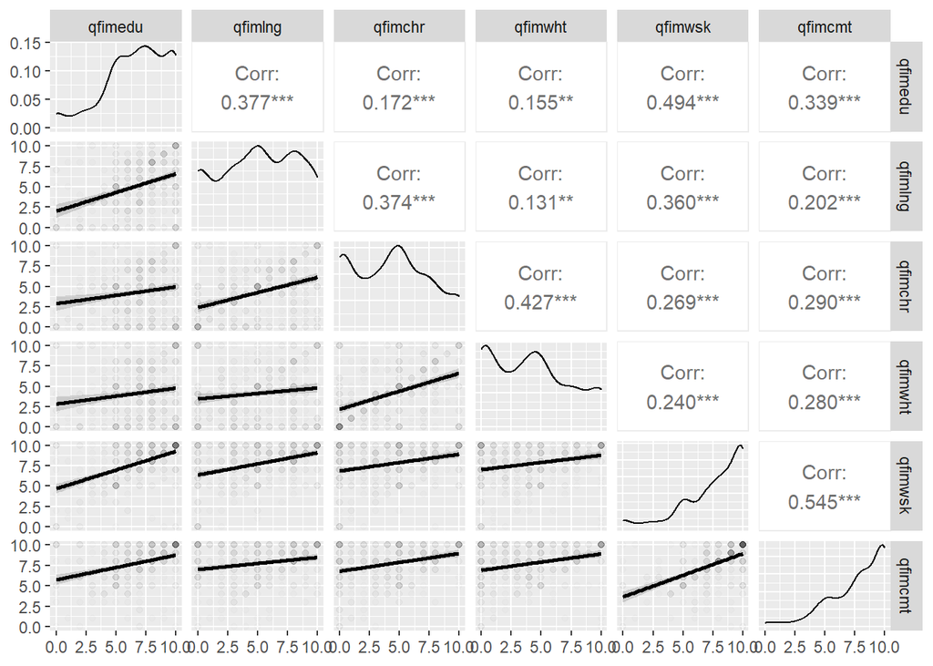

```r
ggpairs(as.data.frame(imp), lower = list(continuous = wrap("smooth", alpha = 0.01)))
```

[figure not shown]

```r
corrgram(imp, lower.panel = panel.ellipse, upper.panel = panel.shade, text.panel = panel.txt, diag.panel = panel.minmax, main = "Erinevate sisserände kriteeriumide olulisus: korrelatsioonimaatriks")
```

Viimane variant annab ka trendijooned, mis põhinevad LOESS-sobitusel, mis on paindlikum kui regressioonil põhinev sirgjoon, aga vahel isegi liiga, et mingeid järeldusi teha. Vahel võivad need jooned olla päris sinka-vonka, nii et tõlgendamine on keeruline ja pigem võiks neid võtta reservatsioonidega. Antud juhul väga palju need jooned lineaarsest seosest ei erine, nii et ei ole tõenäoliselt häda, kui kasutada Pearsoni korrelatsioonikordajaid (nagu me ka tegime).

Ühe tunnuspaari puhul võib kasutada ka lihtsalt `ggplot`’i:

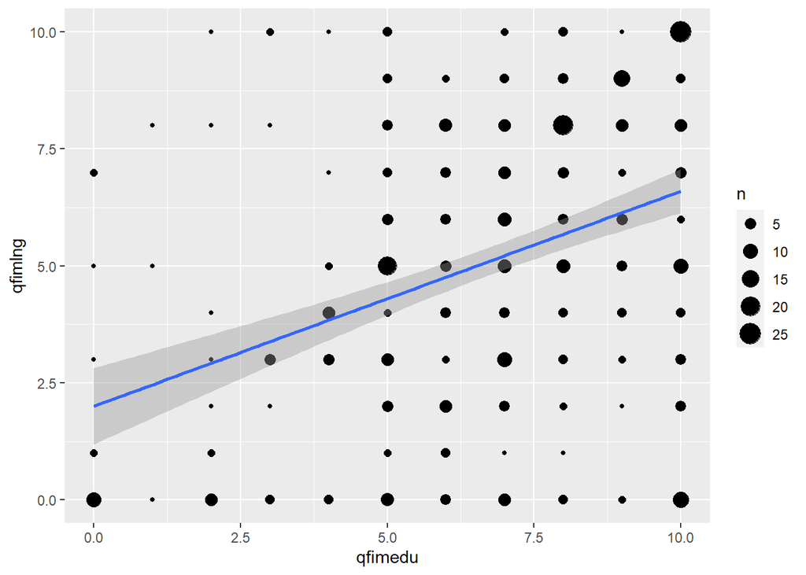

```r
ggplot(as.data.frame(imp), aes(qfimedu, qfimlng)) +
  geom_count() +
  stat_smooth(method = "lm", formula = y ~ x)
```

## Spearmani korrelatsioonikordaja arvutamine

Kui oleksime hajuvusdiagrammidelt siiski tuvastanud, et lineaarseid seoseid ei saa eeldada, oleksime saanud kasutada Spearmani korrelatsioonikordajat (eeldusel, et seoseid saab kirjeldada monotoonsetena):

```r
rcorr(imp, type = "spearman")
```

```
##         qfimedu qfimlng qfimchr qfimwht qfimwsk qfimcmt
## qfimedu    1.00    0.36    0.16    0.14    0.50    0.40
## qfimlng    0.36    1.00    0.37    0.14    0.31    0.18
## qfimchr    0.16    0.37    1.00    0.45    0.21    0.25
## qfimwht    0.14    0.14    0.45    1.00    0.20    0.26
## qfimwsk    0.50    0.31    0.21    0.20    1.00    0.59
## qfimcmt    0.40    0.18    0.25    0.26    0.59    1.00
##
## n
##         qfimedu qfimlng qfimchr qfimwht qfimwsk qfimcmt
## qfimedu     394     390     383     388     392     389
## qfimlng     390     394     385     389     393     388
## qfimchr     383     385     388     384     387     383
## qfimwht     388     389     384     392     391     388
## qfimwsk     392     393     387     391     398     391
## qfimcmt     389     388     383     388     391     392
##
## P
##         qfimedu qfimlng qfimchr qfimwht qfimwsk qfimcmt
## qfimedu         0.0000  0.0018  0.0070  0.0000  0.0000
## qfimlng 0.0000          0.0000  0.0063  0.0000  0.0003
## qfimchr 0.0018  0.0000          0.0000  0.0000  0.0000
## qfimwht 0.0070  0.0063  0.0000          0.0000  0.0000
## qfimwsk 0.0000  0.0000  0.0000  0.0000          0.0000
## qfimcmt 0.0000  0.0003  0.0000  0.0000  0.0000
```

## Lineaarse korrelatsioonikordaja arvutamine kaaludega

Kuidas võtta arvesse kaale? R-s on erinevates pakettides erinevaid funktsioone, mille funktsionaalsus on hea Pearsoni korrelatsioonikordaja osas, Spearmani osas on keerulisem. Näiteks paketis `weights` on funktsioon `wtd.cor`, mis arvutab ainult Pearsoni korrelatsioonikordajad.

Kaasame oma andmestikku ka järelstratifitseerimise kaalu tunnuse ja arvutame kaalutud andmete põhjal korrelatsioonimaatriksi. Väljundis esitatakse iga korrelatsioonikordaja kohta ka standardviga ja *t*-väärtus, seose esinemise kohta otsuse tegemiseks piisab siiski vaid korrelatsioonikordajast ja olulisuse tõenäosusest.

```r
imp2 <- ee7 %>%
  filter(brncntr == 2) %>%
  select(qfimedu:qfimcmt, pspwght)

imp2 %>%
  select(qfimedu:qfimcmt) %>%
  wtd.cor(weight = imp2$pspwght)
```

```
## $correlation
##           qfimedu   qfimlng   qfimchr   qfimwht   qfimwsk   qfimcmt
## qfimedu 1.0000000 0.3811077 0.1788655 0.1521863 0.5211216 0.3254241
## qfimlng 0.3811077 1.0000000 0.3513225 0.1391908 0.3631448 0.2060251
## qfimchr 0.1788655 0.3513225 1.0000000 0.4416523 0.2725162 0.3121913
## qfimwht 0.1521863 0.1391908 0.4416523 1.0000000 0.2616205 0.2823853
## qfimwsk 0.5211216 0.3631448 0.2725162 0.2616205 1.0000000 0.5269963
## qfimcmt 0.3254241 0.2060251 0.3121913 0.2823853 0.5269963 1.0000000
##
## $std.err
##              qfimedu      qfimlng      qfimchr      qfimwht      qfimwsk
## qfimedu 1.068346e-16 4.693593e-02 5.040537e-02 5.030578e-02 4.321776e-02
## qfimlng 4.693593e-02 9.860844e-17 4.784037e-02 5.033803e-02 4.711975e-02
## qfimchr 5.040537e-02 4.784037e-02 1.768630e-16 4.590404e-02 4.903577e-02
## qfimwht 5.030578e-02 5.033803e-02 4.590404e-02 4.230519e-18 4.893610e-02
## qfimwsk 4.321776e-02 4.711975e-02 4.903577e-02 4.893610e-02 1.529254e-16
## qfimcmt 4.806593e-02 4.980672e-02 4.867096e-02 4.882714e-02 4.309000e-02
##              qfimcmt
## qfimedu 4.806593e-02
## qfimlng 4.980672e-02
## qfimchr 4.867096e-02
## qfimwht 4.882714e-02
## qfimwsk 4.309000e-02
## qfimcmt 1.939434e-16
##
## $t.value
##              qfimedu      qfimlng      qfimchr      qfimwht      qfimwsk
## qfimedu 9.360261e+15 8.119742e+00 3.548541e+00 3.025225e+00 1.205804e+01
## qfimlng 8.119742e+00 1.014112e+16 7.343640e+00 2.765121e+00 7.706849e+00
## qfimchr 3.548541e+00 7.343640e+00 5.654095e+15 9.621207e+00 5.557498e+00
## qfimwht 3.025225e+00 2.765121e+00 9.621207e+00 2.363776e+17 5.346166e+00
## qfimwsk 1.205804e+01 7.706849e+00 5.557498e+00 5.346166e+00 6.539134e+15
## qfimcmt 6.770368e+00 4.136492e+00 6.414323e+00 5.783367e+00 1.223013e+01
##              qfimcmt
## qfimedu 6.770368e+00
## qfimlng 4.136492e+00
## qfimchr 6.414323e+00
## qfimwht 5.783367e+00
## qfimwsk 1.223013e+01
## qfimcmt 5.156143e+15
##
## $p.value
##              qfimedu      qfimlng      qfimchr      qfimwht      qfimwsk
## qfimedu 0.000000e+00 6.271129e-15 4.357446e-04 2.650778e-03 1.127607e-28
## qfimlng 6.271129e-15 0.000000e+00 1.260524e-12 5.962545e-03 1.075022e-13
## qfimchr 4.357446e-04 1.260524e-12 0.000000e+00 9.165539e-20 5.119212e-08
## qfimwht 2.650778e-03 5.962545e-03 9.165539e-20 0.000000e+00 1.534793e-07
## qfimwsk 1.127607e-28 1.075022e-13 5.119212e-08 1.534793e-07 0.000000e+00
## qfimcmt 4.781035e-11 4.330868e-05 4.196502e-10 1.513728e-08 2.509992e-29
##              qfimcmt
## qfimedu 4.781035e-11
## qfimlng 4.330868e-05
## qfimchr 4.196502e-10
## qfimwht 1.513728e-08
## qfimwsk 2.509992e-29
## qfimcmt 0.000000e+00
```

Kui soovime maatriksites olevaid arve ümardada ja lahti saada arvude standardkujul esitamisest, ei saa funktsiooni `round` rakendada kõigile maatriksitele korraga, vaid ainult ühele. Selleks eraldame testitulemustest vajaliku maatriksi ja ümardame selles olevad arvud kahe komakohani (olulisuse tõenäosuste puhul võib kolme komakohani):

```r
imp2 %>%
  select(qfimedu:qfimcmt) %>%
  wtd.cor(weight = imp2$pspwght) %>%
  extract2(1) %>%
  round(2)
```

```
##         qfimedu qfimlng qfimchr qfimwht qfimwsk qfimcmt
## qfimedu    1.00    0.38    0.18    0.15    0.52    0.33
## qfimlng    0.38    1.00    0.35    0.14    0.36    0.21
## qfimchr    0.18    0.35    1.00    0.44    0.27    0.31
## qfimwht    0.15    0.14    0.44    1.00    0.26    0.28
## qfimwsk    0.52    0.36    0.27    0.26    1.00    0.53
## qfimcmt    0.33    0.21    0.31    0.28    0.53    1.00
```

```r
imp2 %>%
  select(qfimedu:qfimcmt) %>%
  wtd.cor(weight = imp2$pspwght) %>%
  extract2(4) %>%
  round(3)
```

```
##         qfimedu qfimlng qfimchr qfimwht qfimwsk qfimcmt
## qfimedu   0.000   0.000       0   0.003       0       0
## qfimlng   0.000   0.000       0   0.006       0       0
## qfimchr   0.000   0.000       0   0.000       0       0
## qfimwht   0.003   0.006       0   0.000       0       0
## qfimwsk   0.000   0.000       0   0.000       0       0
## qfimcmt   0.000   0.000       0   0.000       0       0
```

Esitame tulemused ka visuaalselt ja lisame info statistilise olulisuse kohta. Et viimases oleks tunnuspaaride puhul mingeidki erinevusi ja oleks näha erinevus statistiliselt oluliste ja mitteoluliste tulemuste esitamisel, kasutame siin olulisuse nivood 0,001.

Kui soovime joonisele ka infot statistilise olulisuse kohta, siis tuleb olulisuse tõenäosuse maatriksile lisada samad ridade/veergude nimed, mis korrelatsioonikordajate maatriksil.

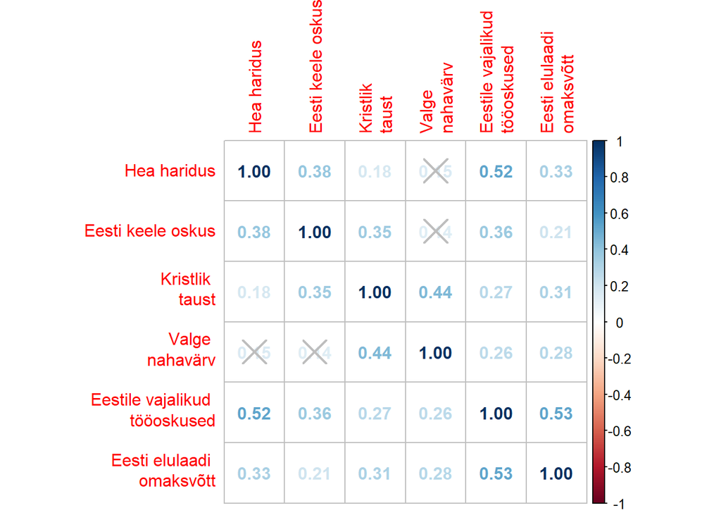

```r
r_wtd <- imp2 %>%
  select(qfimedu:qfimcmt) %>%
  wtd.cor(weight = imp2$pspwght) %>%
  extract2(1)

rownames(r_wtd) <- nimed
colnames(r_wtd) <- nimed

p_wtd <- imp2 %>%
  select(qfimedu:qfimcmt) %>%
  wtd.cor(weight = imp2$pspwght) %>%
  extract2(4)

colnames(p_wtd) <- nimed
rownames(p_wtd) <- nimed

corrplot(r_wtd, method = "number", p.mat = p_wtd, sig.level = 0.001, insig = 'pch', pch.col = 'grey')
```

Näeme, et erinevused kaalumata korrelatsioonikordajatega on siin minimaalsed.

# Spearmani korrelatsioonikordaja arvutamine kaaludega

Pakett `weights` ei anna võimalust arvutada Spearmani korrelatsionikordajat. Erinevates pakettides on selleks võimalusi, aga mõni ei võimalda arvutada korrelatsioonimaatriksit, mõni olulisuse tõenäosusi. Hädast aitab välja asjaolu, et Spearmani korrelatsioonikordaja saame ka siis, kui arvutame tunnuste astakud ja rakendame neile Pearsoni korrelatsioonikordaja arvutamise valemit. Seega olulisuse tõenäosuste saamiseks võiksime kaale arvesse võttes arvutada ise tunnuste väärtuste astakud ja anda funktsioonis `wtd.cor` esimeseks argumendiks astakud, siis saame väljundis Spearmani korrelatsioonikordajate väärtused ja olulisuse tõenäosused:

```r
imp2a <- na.omit(imp2)

imp2a$qfimedu_rank <- wtd.rank(imp2a$qfimedu, weights = imp2a$pspwght)
imp2a$qfimlng_rank <- wtd.rank(imp2a$qfimlng, weights = imp2a$pspwght)
imp2a$qfimchr_rank <- wtd.rank(imp2a$qfimchr, weights = imp2a$pspwght)
imp2a$qfimwht_rank <- wtd.rank(imp2a$qfimwht, weights = imp2a$pspwght)
imp2a$qfimwsk_rank <- wtd.rank(imp2a$qfimwsk, weights = imp2a$pspwght)
imp2a$qfimcmt_rank <- wtd.rank(imp2a$qfimcmt, weights = imp2a$pspwght)

imp2a %>%
  select(qfimedu_rank:qfimcmt_rank) %>%
  wtd.cor(weight = imp2a$pspwght)
```

```
## $correlation
##              qfimedu_rank qfimlng_rank qfimchr_rank qfimwht_rank qfimwsk_rank
## qfimedu_rank    1.0000000    0.3680771    0.1499394    0.1112290    0.5085283
## qfimlng_rank    0.3680771    1.0000000    0.3441548    0.1838758    0.3064219
## qfimchr_rank    0.1499394    0.3441548    1.0000000    0.4643785    0.2162199
## qfimwht_rank    0.1112290    0.1838758    0.4643785    1.0000000    0.2101138
## qfimwsk_rank    0.5085283    0.3064219    0.2162199    0.2101138    1.0000000
## qfimcmt_rank    0.3868106    0.1917178    0.2682544    0.2576006    0.5700707
##              qfimcmt_rank
## qfimedu_rank    0.3868106
## qfimlng_rank    0.1917178
## qfimchr_rank    0.2682544
## qfimwht_rank    0.2576006
## qfimwsk_rank    0.5700707
## qfimcmt_rank    1.0000000
##
## $std.err
##              qfimedu_rank qfimlng_rank qfimchr_rank qfimwht_rank qfimwsk_rank
## qfimedu_rank 4.542127e-17 4.814297e-02 5.119270e-02 5.145674e-02 4.458323e-02
## qfimlng_rank 4.814297e-02 1.921915e-17 4.861507e-02 5.089520e-02 4.928730e-02
## qfimchr_rank 5.119270e-02 4.861507e-02 9.256367e-17 4.585654e-02 5.055321e-02
## qfimwht_rank 5.145674e-02 5.089520e-02 4.585654e-02 3.369586e-18 5.062219e-02
## qfimwsk_rank 4.458323e-02 4.928730e-02 5.055321e-02 5.062219e-02 4.510352e-17
## qfimcmt_rank 4.774759e-02 5.081756e-02 4.988027e-02 5.003060e-02 4.254061e-02
##              qfimcmt_rank
## qfimedu_rank 4.774759e-02
## qfimlng_rank 5.081756e-02
## qfimchr_rank 4.988027e-02
## qfimwht_rank 5.003060e-02
## qfimwsk_rank 4.254061e-02
## qfimcmt_rank 9.414326e-17
##
## $t.value
##              qfimedu_rank qfimlng_rank qfimchr_rank qfimwht_rank qfimwsk_rank
## qfimedu_rank 2.201612e+16 7.645500e+00 2.928922e+00 2.161603e+00 1.140627e+01
## qfimlng_rank 7.645500e+00 5.203144e+16 7.079179e+00 3.612832e+00 6.217056e+00
## qfimchr_rank 2.928922e+00 7.079179e+00 1.080337e+16 1.012677e+01 4.277076e+00
## qfimwht_rank 2.161603e+00 3.612832e+00 1.012677e+01 2.967724e+17 4.150627e+00
## qfimwsk_rank 1.140627e+01 6.217056e+00 4.277076e+00 4.150627e+00 2.217122e+16
## qfimcmt_rank 8.101154e+00 3.772668e+00 5.377965e+00 5.148861e+00 1.340062e+01
```

[output cut: 8 more lines]

```
## $p.value
##              qfimedu_rank qfimlng_rank qfimchr_rank qfimwht_rank qfimwsk_rank
## qfimedu_rank 0.000000e+00 1.783323e-13 3.610350e-03 3.128440e-02 4.687199e-26
## qfimlng_rank 1.783323e-13 0.000000e+00 7.245253e-12 3.443600e-04 1.357647e-09
## qfimchr_rank 3.610350e-03 7.245253e-12 0.000000e+00 1.867109e-21 2.408966e-05
## qfimwht_rank 3.128440e-02 3.443600e-04 1.867109e-21 0.000000e+00 4.111469e-05
## qfimwsk_rank 4.687199e-26 1.357647e-09 2.408966e-05 4.111469e-05 0.000000e+00
## qfimcmt_rank 7.844112e-15 1.877843e-04 1.332191e-07 4.250914e-07 1.059187e-33
##              qfimcmt_rank
## qfimedu_rank 7.844112e-15
## qfimlng_rank 1.877843e-04
## qfimchr_rank 1.332191e-07
## qfimwht_rank 4.250914e-07
## qfimwsk_rank 1.059187e-33
## qfimcmt_rank 0.000000e+00
```

Spearmani korrelatsioonikordajad ja nende olulisuse tõenäosused ümardatult.

```r
imp2a %>%
  select(qfimedu_rank:qfimcmt_rank) %>%
  wtd.cor(weight = imp2a$pspwght) %>%
  extract2(1) %>%
  round(2)
```

```
##              qfimedu_rank qfimlng_rank qfimchr_rank qfimwht_rank qfimwsk_rank
## qfimedu_rank         1.00         0.37         0.15         0.11         0.51
## qfimlng_rank         0.37         1.00         0.34         0.18         0.31
## qfimchr_rank         0.15         0.34         1.00         0.46         0.22
## qfimwht_rank         0.11         0.18         0.46         1.00         0.21
## qfimwsk_rank         0.51         0.31         0.22         0.21         1.00
## qfimcmt_rank         0.39         0.19         0.27         0.26         0.57
##              qfimcmt_rank
## qfimedu_rank         0.39
## qfimlng_rank         0.19
## qfimchr_rank         0.27
## qfimwht_rank         0.26
## qfimwsk_rank         0.57
## qfimcmt_rank         1.00
```

```r
imp2a %>%
  select(qfimedu_rank:qfimcmt_rank) %>%
  wtd.cor(weight = imp2a$pspwght) %>%
  extract2(4) %>%
  round(3)
```

```
##              qfimedu_rank qfimlng_rank qfimchr_rank qfimwht_rank qfimwsk_rank
## qfimedu_rank        0.000            0        0.004        0.031            0
## qfimlng_rank        0.000            0        0.000        0.000            0
## qfimchr_rank        0.004            0        0.000        0.000            0
## qfimwht_rank        0.031            0        0.000        0.000            0
## qfimwsk_rank        0.000            0        0.000        0.000            0
## qfimcmt_rank        0.000            0        0.000        0.000            0
##              qfimcmt_rank
## qfimedu_rank            0
## qfimlng_rank            0
## qfimchr_rank            0
## qfimwht_rank            0
## qfimwsk_rank            0
## qfimcmt_rank            0
```

Kõik olulisuse tõenäosused on nagu eelnevategi tulemuste puhul väga madalad.

## Ülesanne 2

Kas / kuidas on omavahel seotud haridus ja usaldus erinevate institutsioonide vastu töötute seas? Hinnake seoste olemasolu lineaarse korrelatsioonikordaja alusel. Võtke aluseks ESS-i 9. laine kaalutud andmed:

- haridustee pikkus: `eduyrs`
- usaldus erinevate institutsioonide vastu: `trstprl:trstprt`
- töötud: väärtus 1 tunnustes `uempla` ja `uempli`

Andmete sisselaadimine:

```r
ee9 <- read_spss("data/ee9.sav")
```

Esitage ülesande lahendus kas:

- Rmarkdowniga tehtud html-failina või
- nagu varasemalt skriptifailis, kuhu lisage ka lahenduseni jõudmiseks vajalikud eelnevad käsud (nt pakettide laadimine, andmete sisselugemine).

Proovige ülesanne teha kõigepealt iseseisvalt eelneva koodi põhjal. Kui see ei õnnestu, siis…

**väljundi nägemiseks klikkige siia**

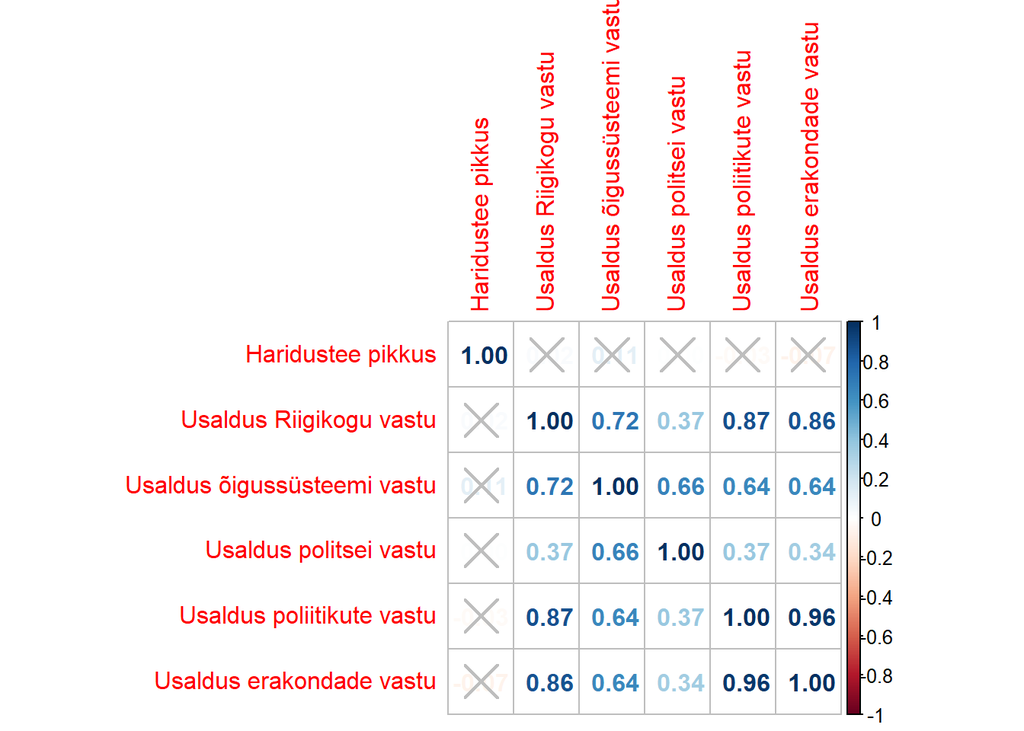

**lahenduse nägemiseks klikkige siia**

```r
unemployed <- ee9 %>%
  filter(uempla == 1 | uempli == 1)

r_wtd_unempl <- unemployed %>%
  select(eduyrs, trstprl:trstprt) %>%
  wtd.cor(weight = unemployed$pspwght) %>%
  extract2(1) %>%
  round(2)

p_wtd_unempl <- unemployed %>%
  select(eduyrs, trstprl:trstprt) %>%
  wtd.cor(weight = unemployed$pspwght) %>%
  extract2(4) %>%
  round(3)

nimed_unempl <- c("Haridustee pikkus", "Usaldus Riigikogu vastu", "Usaldus õigussüsteemi vastu", "Usaldus politsei vastu", "Usaldus poliitikute vastu", "Usaldus erakondade vastu")

colnames(r_wtd_unempl) <- nimed_unempl
rownames(r_wtd_unempl) <- nimed_unempl
colnames(p_wtd_unempl) <- nimed_unempl
rownames(p_wtd_unempl) <- nimed_unempl

corrplot(r_wtd_unempl, method = "number", p.mat = p_wtd_unempl, sig.level = 0.01, insig = 'pch', pch.col = 'grey')
```